# Radiation and Optics

Based on BTV 1ed *1. Introduction*

Author

Pedro J. Aphalo with Andreas Albert, Lars Olof Björn, Lasse Yliantilla

Abstract

This chapter discusses radiation-physics and optics from the point of view of biological systems and their scientific and practical study.

**I have retained the use of quantity symbols and names from the first edition. The SI system was updated in 2018 and the IUPAC Gold Book in 2020. I/we have to check that the symbols and nomenclature we use are up-to-date with these updates.**

## Wavelength and Colour

Radiation, or radiant energy, can be described as waves, with wavelength or frequency as properties, or based on quantum physics, as photons of specific energy. This “double personality” of light is important as each approach provides a simpler explanation than the other one for different specific phenomena, such as refraction and reflection at boundaries between materials and absorption of radiation by pigments and other molecules. From the first perspective, ultraviolet (UV), visible (VIS), and infrared (IR) radiation are electromagnetic waves and are described by the Maxwell’s equations.[^1] From the second perspective, Plank’s law describes the energy of a quantum as inversely proportional to wavelength.

The wavelength ranges of visible radiation, described by their colour based on human vision’s response to monochromatic light, are shown in Figure 1, topmost bar of wavebands. The colour ranges indicated in Figure 1 are one approximation out of several available. We follow the ISO and CIE standards when applicable. The electromagnetic spectrum is continuous with no clear boundaries between one colour and the next. Colours are the result of the interaction of different wavelengths of radiation with the photoreceptor pigments in the eye and the processing of the stimuli by the brain. Alternative definitions based on other sensory systems or energy capture systems are available, some of them applicable to plants are shown in Figure 1, two lowermost bars of wavebands.

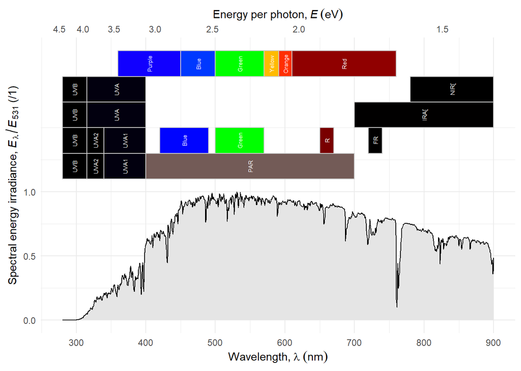

Figure 1: The solar spectrum, $280-900\,\mathrm{nm}$, and different commonly used *named* wavebands. The solar spectrum at ground level for 1.5 air masses (ASTM G173 standard) and, from top to bottom, human-vision colours according to ISO 21348, UV and IR bands according to ISO 21348, UV and IR bands according to CIE, colours as frequently defined in plant photobiology (Sellaro et al. 2010; Smith 1981), and PAR (McCree 1972).

Different regions or *wavebands* of UV and IR radiation are also shown in Figure 1, but only in the proximity of visible radiation. In Figure 2 they are shown for a wider range of wavelengths. It is important to keep in mind that the ISO and CIE definitions of the VIS and UV wavebands overlap. Thus, it is incorrect to sum VIS and UV irradiances, while the definitions of photosynthetically active radiation (PAR) and UV do not overlap. Especially in the IR region, the subdivision is somewhat arbitrary and the boundaries used in the literature vary, with differences even between ISO and CIE standards.

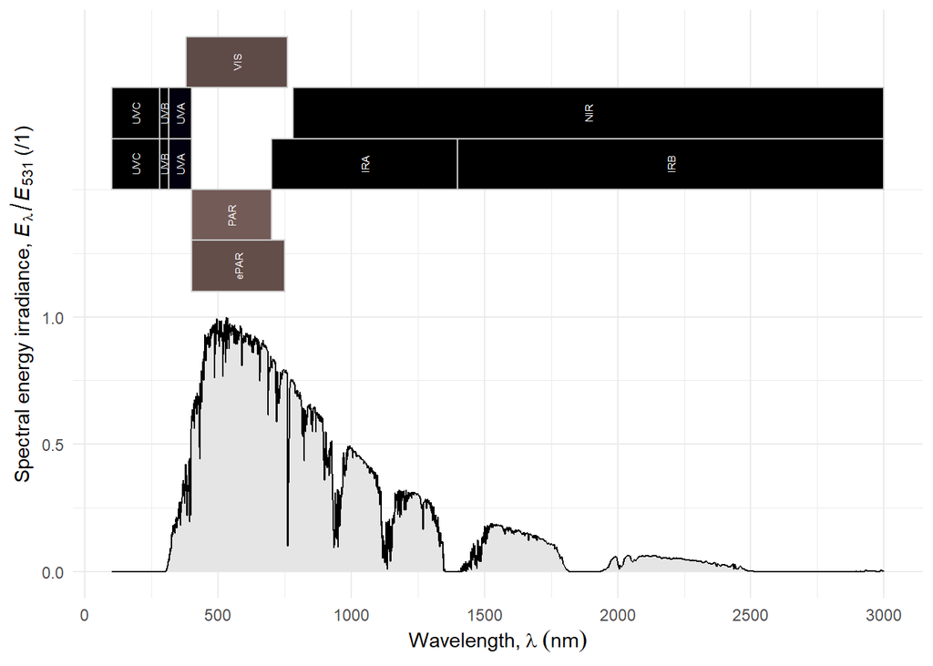

The energy of a quantum of radiation in a vacuum, depends on the wavelength, $\lambda$, or frequency[^2], $\nu$,

$$q = h \cdot \nu = h \cdot \frac{c}{\lambda}$$

with the Planck constant $h=6.626\times 10^{-34}\,\mathrm{J\,s}$ and speed of light in vacuum $c=2.998\times 10^{8}\,\mathrm{m}\,\mathrm{s}^{-1}$. When dealing with numbers of photons, the equation above can be extended by using Avogadro’s number $N_\mathrm{A}=6.022\times 10^{23}$ mol$^{-1}$. Thus, the energy of one mole of photons, $q^\prime$, is

$$q^\prime = h^\prime \cdot \nu = h^\prime \cdot \frac{c}{\lambda}$$
with $h'=h\cdot N_\mathrm{A}=3.990\times 10^{-10}\,\mathrm{J\,s\,mol}^{-1}$.

The two equations above, are valid for all kinds of electromagnetic waves.

**examples**

**Example 1:** red light at 600 nm has about 200 kJ mol$^{-1}$, therefore, 1 $\mu$mol photons has 0.2 J. **Example 2:** radiation at 300 nm has about 400 kJ mol$^{-1}$, therefore, 1 $\mu$mol photons has 0.4 J.

## Angle of Incidence

Most frequently we describe the flux of radiation on a plane, usually, but not always a horizontal plane Figure 3. This flux is called *irradiance* and expressed per unit area and unit time. The area used as a reference is that of the receiving plane. Fluence rate is measured on the surface of a sphere instead of a plane. In this case, the plane is located in three-dimensional (3D) space. When considering a point source of radiation, the angle, $\alpha$, between the light beam and the receiving plane or surface affects the received irradiance: the shallower the angle of incidence the lower the irradiance from the same beam of light. Both irradiance and fluence rate are fluxes of radiation, expressed per unit area and unit time Figure 3. In the first case the area is that of the illuminated planar surface and in the second case of an spherical surface.

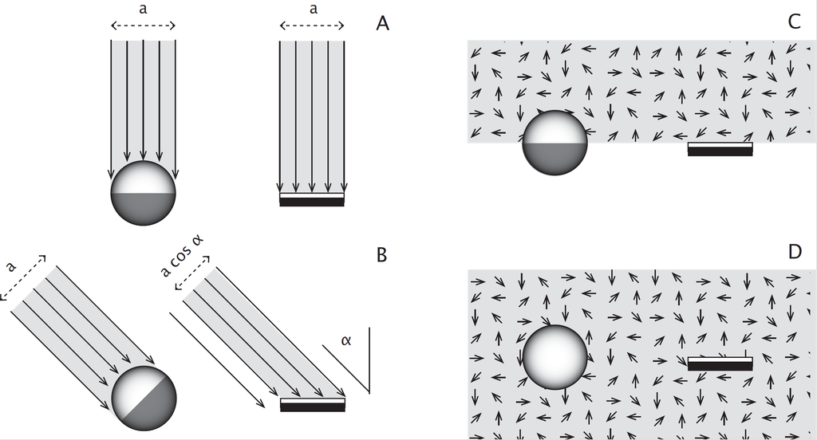

Figure 3: The concepts of irradiance and fluence rate explained. (A) A beam of radiation perpendicular to the plane of an irradiance sensor; irradiance and fluence rate have the same numerical value. (B) Radiation beam at an angle to the irradiance sensor; irradiance has a smaller numerical value than fluence rate. (C) Perfectly diffuse radiation from the hemisphere above the irradiance sensor; the numerical value of irradiance is one half that of fluence rate. (D) Perfectly diffuse radiation from both hemispheres, both above and below the sensors; the numerical value of irradiance is one quarter that of fluence rate. A spherical sensor (left) measures fluence rate, and a one-sided planar sensor (right) measures irradiance. In (A) and (B) radiation is collimated and represented by parallel arrows. In (C) and (D) radiation is diffuse and represented by “randomly” oriented arrows. In (A), (B) and (C) the shaded hemisphere of the spherical sensor is grey.

**Sensors and their shape**

There are, in principle, two possible approaches to measuring radiation. The first is to observe light from one specific direction or viewing angle, which is the radiance $L$. The second is to use a detector, which senses radiation from more than one direction and measures radiation impinging it from all directions from an enclosing sphere or hemisphere. The relation between irradiance $E$ and radiance $L$ at wavelength $\lambda$ is given by integrating incoming photons over these directions.

$$\begin{aligned}
E[0](\lambda) & = \int_\Omega L(\lambda,\Omega) {\rm d}\Omega \label{equ_E0} \\
E(\lambda) & = \int_\Omega I(\lambda,\Omega) |\cos\alpha| {\rm d}\Omega \label{equ_E}
%\end{eqnarray}
\end{aligned}$$

The shape of a detector entrance-optics, planar or spherical, determines the measured physical quantity, and the weight given to photons from different directions Figure 3. Collection of light on a flat surface (or equivalently through an small opening in an integrating sphere) yields irradiance, energy irradiance, $E$, or photon irradiance, $Q$ depending on the spectral response of the detector. A spherical collecting surface, yields fluence rate (also called scalar irradiance) $E_0$, $Q_0$. In practice, all spherical sensors have a blind stop due to necesary support and connection to a readout device.

The sun, can be assumed to be a point source (the solar disk is $\approx 1 ^\circ$ in diameter when seen from Earth). Changes in distance that are of interest when studying plants are extremely small relative to the total Sun to Earth distance and can be ignored. Thus, in the case of direct sunlight, we have to consider only the angle of incidence. For a given light source the maximum irradiance is that received on a plane normal to the light beam Figure 3. As the angle between the beam and the surface becomes shallower, the irradiance measured on the plane decreases, reaching zero, when the beam is parallel to the surface. The relationship between the normal area and that at a shallower angle is given by the cosine of the angle $\alpha$. When considering the sun, if the receiving plane is horizontal, the angle of interest is the zenith angle (1 - solar elevation angle) Figure 4. If the plane is not horizontal, the angle between the plane and the light beam depends both the the zenith angle and the azimuth angle of the sun’s position, and the effective angle needs to be computed in three dimensions.

[figure not shown]

Figure 4: Asimuth and elevation (= Altitude) angles (**diagram to be redrawn or edited!**). If the plane on which irradiance is measured is horizontal, the Azimuth angle does not affect the incident angle, and it is enough to only take into account the elevation angle. *By TWCarlson* - Azimut altitude.svg, CC BY-SA 3.0 [file at wikimedia.org](https://commons.wikimedia.org/w/index.php?curid=17727911).

Obviously, the discussion above ignored scattered radiation from the sky. One approach to the simulation of the light field when multiple sources or sources with a large emitting area are present, is to use ray tracing, which is essentially a divide and conquer approach.

When we considered *a point source* like a bare LED chip or light from a small light bulb at a relatively short distance from the receiving plane, distance cannot be ignored as done above for the sun, as the illuminated area increases four times for each doubling in the distance. Thus, each doubling in distance decreases irradiance by 75%.

In the case of light sources with a large surface relative to the illuminated area or light beams focused by a lens or reflector, the rate of increase in area is smaller than for a point source. The extreme case is a highly collimated laser beam, for which the illuminated area increases very slowly with increasing distance. The irradiance, in these cases, is frequently not uniform within the illuminated area, with in most cases higher iradiance at the centre than at the edges of the illuminated area.

**Tip**

Using a lens or reflector to make a light beam narrower makes it possible to increase irradiance by concentrating the light energy onto a smaller illuminated area, and this effect can be quantitatively large. Alternatively, the narrower beam makes it possible to move the light source away from the illuminated object maintaining the same irradiance. This can provide additional space for other equipment, or when using selective reflectors that transmit infrared radiation and only reflect VIS and/or UV radiation reduce the heat load on the illuminated object.

In a perfectly collimated beam, the photons follow parallel trajectories. In a beam from a ideal point source the trajectories of the photons are equally probable in all directions (away from the centre of an imaginary sphere). Most real light sources behave somewhere in between these extremes.

**Angle of Incidence in 3D**

While in Figure 4, we had the sensor or observer at the centre, and the light source located on an imaginary sphere, here, instead, we locate the point light source at the centre of the sphere. So, when a beam or the radiation passing into a space or sphere is analysed, two important parameters are necessary: the distance to the source and the position of the measurement plane—i.e., if the receiving surface is perpendicular to the beam or at a shallower angle. The geometry is illustrated in Figure 5. The radiation is received at distance $r$ by a surface of area d$A$, tilted by an angle $\alpha$ to the unit sphere’s surface element, a solid angle, d$\Omega$, which is a two-dimensional angle in a space. The relation between d$A$ and d$\Omega$ in spherical coordinates is geometrically explained in Figure 5.

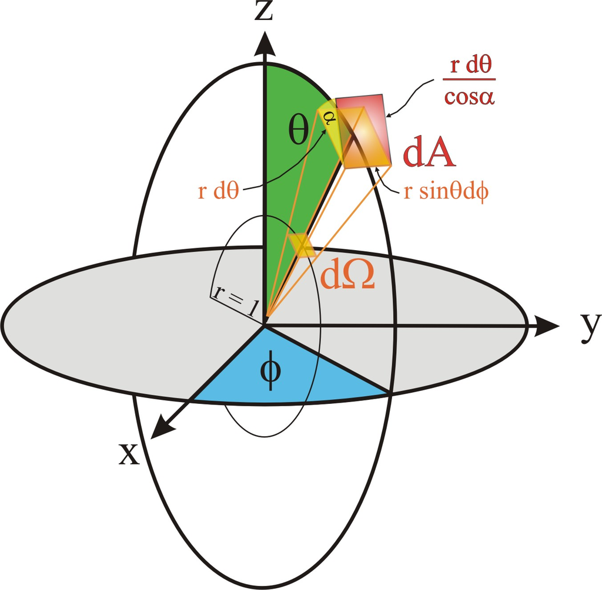

Figure 5: Definition of the solid angle dΩ and the geometry of areas in the space (redrawn after Eichler et al. 1993), where the given solid angle dΩ remains the same, regardless of distance r , while the exposed area exemplified by dA will change with distance r from the origin (light source) and the angle α, if the exposed area (or detector) is tilted. The angle denoted by φ is the azimuth angle and θ is the zenith angle.

The solid angle is calculated from the zenith angle $\theta$ and azimuth angle $\phi$, which denote the direction of the radiation beam

$${\rm d}\Omega = {\rm d}\theta\cdot\sin\theta{\rm d}\phi \label{equ_dsolidangle}$$
The area of the receiving surface is calculated by a combination of the solid angle of the beam, the distance $r$ from the radiation source and the angle $\alpha$ of the tilt:

$${\rm d}A = \frac{r{\rm d}\theta}{\cos\alpha}\cdot r\sin\theta{\rm d}\phi$$
which can be rearranged to

$$\Rightarrow {\rm d}A = \frac{r^2}{\cos\alpha}\quad{\rm d}\Omega$$
Thus, the solid angle is given by

$$\Omega = \int_A \frac{{\rm d}A\cdot\cos\alpha}{r^2} \label{equ_solidangle}$$
The unit of the solid angle is a steradian (sr). The solid angle of an entire sphere is calculated by integration of the equation above over the zenith ($\theta$) and azimuth ($\phi$) angles, $0\le\theta\le\pi(180^\circ)$ and $0\le\phi\le2\pi(360^\circ)$, and is $4\pi$ sr.

### Radiation Quantities

Table 1: Energy based radiation quantities. Commonly used symbols and units in the SI (Systeme Internationale).

[output not shown]

Taking into account Figure 5, the corresponding equations and assuming a homogenous flux, the relation between irradiance $E$ and intensity $I$ is given by
$$E = \frac{I \times \cos\alpha}{r^2} \label{equ_r2law}$$
. The irradiance decreases by the square of the distance to the source and depends on the tilt of the detecting surface area, $\alpha$. This is valid only for theretical point sources, and a good approximation for small ones. For outdoor measurements the sun can be assumed to be a point source. For artificial light sources simple LEDs (light-emitting diodes) without optics on top are also effectively point sources. However, LEDs with optics—and other artificial light sources with optics or reflectors designed to give a narrower light beam—deviate to various extents from the rule of a decrease of irradiance proportional to the square of the distance from the light source.

Table 2: Photon-based radiation quantities. Commonly used symbols and units in the SI (Systeme Internationale).

| Symbol | Unit | Description |
| --- | --- | --- |
| $\Phi_\mathrm{p}$ | s$^{-1}$ | Photon flux: number of photons per time interval |
| $Q=\frac{\partial \Phi_\mathrm{p}}{\partial A}$ | m$^{-2}$ s$^{-1}$ | Photon irradiance: photon flux towards a surface area, photon flux density (earlier frequently called *photon flux density* and abbreviated as PFD) |
| $H_p=\int_t\;Q\;\mathrm{d}t$ | m$^{-2}$ | Photon exposure: number of photons towards a surface area during a time interval, photon fluence |

If we have measured (energy) irradiance, and want to convert this value to photon irradiance, the exact conversion will be possible only if we have information about the spectral composition of the measured radiation. Conversion factors at different wavelengths are given below in Table 3. For “average daylight” in the wavelength band 400 to 700 nm the conversion factor is approximately $4.6\,\mathrm{\mu mol\,J^{-1}}$. This is exact at a wavelength at 550 nm, and will deviate depending on the shape of the spectrum.

Table 3: Energy per photon and conversion factors between photon and energy quantities at different wavelengths. The factors assume $Q$ values are expressed as $\mathrm{\mu mol\,m^{-2}\,s^{-1}}$ and $I$ values as $\mathrm{W\,m^{-2}}$. The factors have units of $\mathrm{\mu mol\,J^{-1}}$ and $\mathrm{J\,\mu mol^{-1}}$ can be also used in the conversion of other quantities.

| $\lambda$ (nm) | $q$ $\mathrm{(eV)}$ | $k, I_\lambda \to Q_\lambda$ $(\mathrm{\mu mol\,J^{-1}})$ | $k, Q_\lambda \to I_\lambda$ $(\mathrm{J\,\mu mol^{-1}})$ |
| --- | --- | --- | --- |
| 250 | 4.96 | 2.09 | 0.479 |
| 300 | 4.13 | 2.51 | 0.399 |
| 350 | 3.54 | 2.93 | 0.342 |
| 400 | 3.10 | 3.34 | 0.299 |
| 450 | 2.76 | 3.76 | 0.266 |
| 500 | 2.48 | 4.18 | 0.239 |
| 550 | 2.25 | 4.60 | 0.218 |
| 600 | 2.07 | 5.02 | 0.199 |
| 650 | 1.91 | 5.43 | 0.184 |
| 700 | 1.77 | 5.85 | 0.171 |
| 750 | 1.65 | 6.27 | 0.160 |
| 800 | 1.55 | 6.69 | 0.150 |
| 850 | 1.46 | 7.11 | 0.141 |
| 900 | 1.38 | 7.52 | 0.133 |

### Effective radiation quantities

Besides the physical quantities used for all electromagnetic radiation, there are also equivalent spectrally weighted quantities used to assess the effect of radiation on sensory systems, photochemical reactions and photobiological responses.

The most widely used biologically effective quantities are photometric quantities, describing the apparent brightness of light to the human eye. Although quantitatively irrelevant to systems other that human vision, they are commonly used by lamp manufacturers to describe light output of artificial light sources. Photometric sensors are also the most widely available. Photometric or illumination quantities are expressed in different units than those of physical quantities.

**Photometric quantities**

In contrast to (spectro-)radiometry, where the energy of any electromagnetic radiation is measured in terms of absolute power ($J\,s^{-1} = W$), photometry measures light as perceived by the human eye. Therefore, radiation is weighted by a luminosity function or visual sensitivity function describing the wavelength dependent response of the human eye. Due to the physiology of the eye, having rods and cones as light receptors, different sensitivity functions exist for the day (photopic vision) and night (scotopic vision), $V(\lambda)$ and $V'(\lambda)$, respectively Figure 6. The maximum response during the day is at $\lambda=555$ nm and during night at $\lambda=507$ nm. Both response functions (normalised to their maximum) are shown in the figure below as established by the Commission Internationale de l’Éclairage (CIE, International Commission on Illumination, Vienna, Austria) in 1924 for photopic vision and 1951 for scotopic vision (Schwiegerling 2004). The data are available from the [Colour and Vision Research Laboratory](http://www.cvrl.org). The photopic response, $V(\lambda)$, is used as the basis of all photometric measurements. However, for very low irradiance, it is possible to compute similar quantities using the scotopic response $V'(\lambda)$.

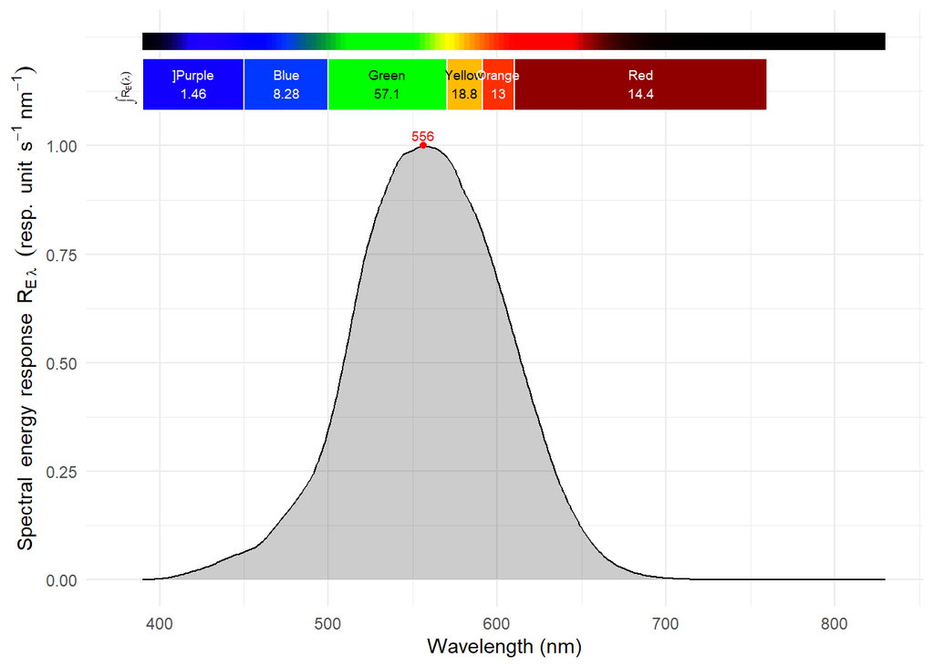

Figure 6: Photopic response of the human eye, $V(\lambda)$, normalised. This is the 2 degrees curve. The numbers in the colour bar, indicate the relative sensitivity, as a percent, to different colours of light as defined in standard ISO 21348.

**Note:** It is important to be aware that these response curves are based on a small number of subjects and, due to variation, not necessarily representative of any individual person, or even of persons of different age or of other ethnicities than those in the study in which the data for the curves were obtained.

If we convolute (multiply wavelength by wavelength) the photopic response spectrum with a spectral irradiance we obtain a new curve Figure 7. The area under this curve, multiplies by a constant, is a measure of the perceived brightness of the light by a “typical” human observer, in this case, $E_\mathrm{v} = 103\,\mathrm{klx}$.

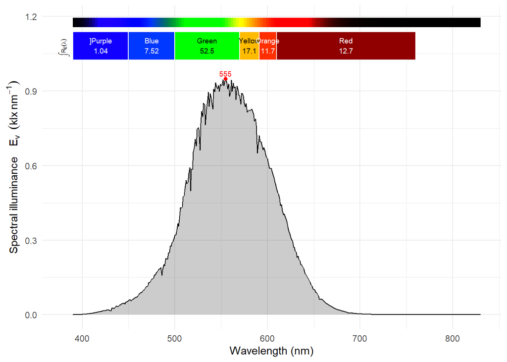

Figure 7: Photopic response of the human eye, $V(\lambda)$ from Figure 6 convoluted by the AM1.5 solar spectrum from Figure 1. The area under the curve, is a measure of brightness as perceived by a human. The numbers in the colour bar, indicate the relative contribution, as a percent, of different colours of light as defined in standard ISO 21348.

Corresponding to the physical quantities of radiation summarized in Table 1 above, the equivalent photometric quantities are listed in the Table 4 below and have the subscript $\mathrm{v}$. The ratio between the (physiological) luminous flux $\Phi_\mathrm{v}$ and the (physical) radiant flux $\Phi$ is the (photopic) photometric equivalent $K(\lambda)=V(\lambda)\times K_m$ with $K_m=683$ lm W$^{-1}$ (lumen per watt) at 555 nm. The dark-adapted sensitivity of the eye (scotopic vision) has its maximum at 507 nm with 1700 lm W$^{-1}$. The base unit of luminous intensity is candela (cd). One candela is defined as the monochromatic intensity at 555 nm with $I=\frac{1}{683}$ W sr$^{-1}$. The luminous flux of a normal candle is around 12 lm. Assuming a homogeneous emission into all directions, the luminous intensity is about $I_v=\frac{12\;\mathrm{lm}}{4\pi\;\mathrm{sr}}\approx 1$ cd.

Table 4: Photometric quantities. Commonly used symbols and units in the SI (Systeme Internationale).

| Symbol | Unit | Description |
| --- | --- | --- |
| $e_\mathrm{v}$ | lm s | Luminous energy or quantity of light |
| $\Phi_\mathrm{v}=\frac{\partial e_\mathrm{v}}{\partial t}$ | lm | Luminous flux: absorbed or emitted luminous energy per time interval |
| $I_\mathrm{v}=\frac{\partial \Phi_\mathrm{v}}{\partial\Omega}$ | cd = lm sr$^{-1}$ | Luminous intensity: emitted luminous flux of a surface area per solid angle |
| $E_\mathrm{v}=\frac{\partial \Phi_\mathrm{v}}{\partial A}$ | lux = lm m$^{-2}$ | Illuminance: luminous flux towards a surface area |
| $\epsilon_\mathrm{v}=\frac{\partial \Phi_\mathrm{v}}{\partial A}$ | lux | Luminous emittance: luminous flux per surface area |
| $H_\mathrm{v}=\frac{\partial e_\mathrm{v}}{\partial A}$ | lux s | Light exposure: quantity of light towards a surface area |
| $L_\mathrm{v}=\frac{\partial^2 \Phi_\mathrm{v}}{\partial \Omega (\partial A\cdot \cos\alpha)}=\frac{\partial I_v}{\partial A\cdot\cos\alpha}$ | cd m$^{-2}$ | Luminance: luminous flux per solid angle and surface area depending on the angle between luminous flux and surface perpendicular |

Photosynthetically active radiation (PAR), is also an effective radiation quantity, proposed in the early 1970’s (McCree 1972). PAR is expressed in physical units as a flux of photons of wavelengths between 400 and 700 nm. Before its widespread acceptance and the widespread availability of PAR or “quantum” light sensors, both energy and photometric quantities were frequently used in research on plants and vegetation. Very long term series of global radiation are available, while those for PAR are shorter and fewer.

In the case of UV radiation, different biologically effective weightings are used, mostly to describe damage or inhibition. These quantities are normally expressed using energy flux units. However, these are *weighted* values that do not describe an energy flux but instead a value assumed to be proportional to a response such as growth inhibition (thus based on the same approach as used for photometric quantties).

## Interactions of Light with Matter

### Reflection

Collimated light reflected from a mirror surface remains collimated, while its direction changes. Light reflected from a white surface is scattered, and if previously collimated, after being reflected it becomes more diffuse, i.e., it leaves the surface in multiple directions. A black surface does not reflect the incident light, it absorbs it. A clear or transparent object transmits all the light incident on its surface, similarly to reflection from mirrors and white surfaces, a clear object can scatter the light passing through it or not. Real objects share some of the properties of these theoretical objects. For example, the atmosphere is not perfectly clear and does partly scatter and partly absorb radiation, depending on the wavelength of the incoming or outgoing radiation. The same applies to water. In both cases, interactions take place as the light travels through them, as well as at the interface between media with different refractive index.

Specular reflection, like in a mirror, affects the angle of the beam consitently, thus, preserving the image. Diffuse reflection consists in scattered light, thus the image is not preserved, light on a white matte wall Figure 8. The sum of specular and diffuse reflection is called total reflection.

$$R^\mathrm{tot} = R^\mathrm{spcl} + R^\mathrm{diff}$$

[figure not shown]

Figure 8: Specular and diffuse reflection [source](https://commons.wikimedia.org/wiki/File:Lambert2.svg) temporary fill to be replaced by figure redrawn from Gates, D (1980) Figure 8.35.

**Gloss**

Gloss is assessed as specular reflectance. Depending on the type of surface, different angles of incidence for the collimated light beam are used. “Gloss meters” are frequently used in industrial quality control, but have been occasonally used to characterize the surface optical properties of individual plant leaves (add reference).

At the boundary between two materials with different refractive index, the direction of the light beam changes, and depending on the difference in refractive index and the angle of incidence, a varying fraction of the incident light is reflected at the interface (Figure 9). On a flat surface like a glass plate or polished metal surface the applicable equation is that derived from Snell’s law, which mathematically is given by

$$n_1 \times sin(\theta_1) = n_2 \times sin(\theta_2)$$

where $n_1$ and $n_2$ are the refractive indexes of two materials, such as air and glass, and $\theta_1$ and $\theta_2$ and the refraction angles.

Reflectance can be estimated from the difference in refractive index and the angle of incidende of the light onto the plane of the interface. Reflectance depends on the contribution of $s$ and $p$ polarised components.

$$R_p = \left(\frac{n^2 \times \cos(\theta) - \sqrt{n^2 - \sin(\theta)^2}}
{n^2 \times \cos(\theta) +
\sqrt{n^2 - \sin(\theta)^2}}\right)^2$$

and

$$R_s = \left(\frac{\cos(\theta) - \sqrt{n^2 - \sin(\theta)^2}}
{\cos(\theta) +
\sqrt{n^2 - \sin(\theta)^2}}\right)^2$$

Combining both formulas above, weighted based on the contributions of $p$ and $s$ components. The reflectance of a single interface can be calculated as

$$R = R_p \times f_p + R_s \times f_s$$

with $f_p + f_s = 1$, for the fraction of the radiation with $p$ and $s$ polarization planes. Using these equations, the reflectance at a glass window in contact with air of both sides can be computed. The refractive index of air is 1 and that of glass 1.5, so reflectance for a relative refractive index of $n = 1.5$ is shown in Figure 9 simulates a single and a double interface.

The reflectance for two surfaces can be computed taking into account multiple back and forth reflections within the glass pane as well as its internal absorbance, or *approximated* ignoring them, as in Figure 9. For a clear glass pane the error is not too large, but for some other materials could cause significant bias in the estimates.

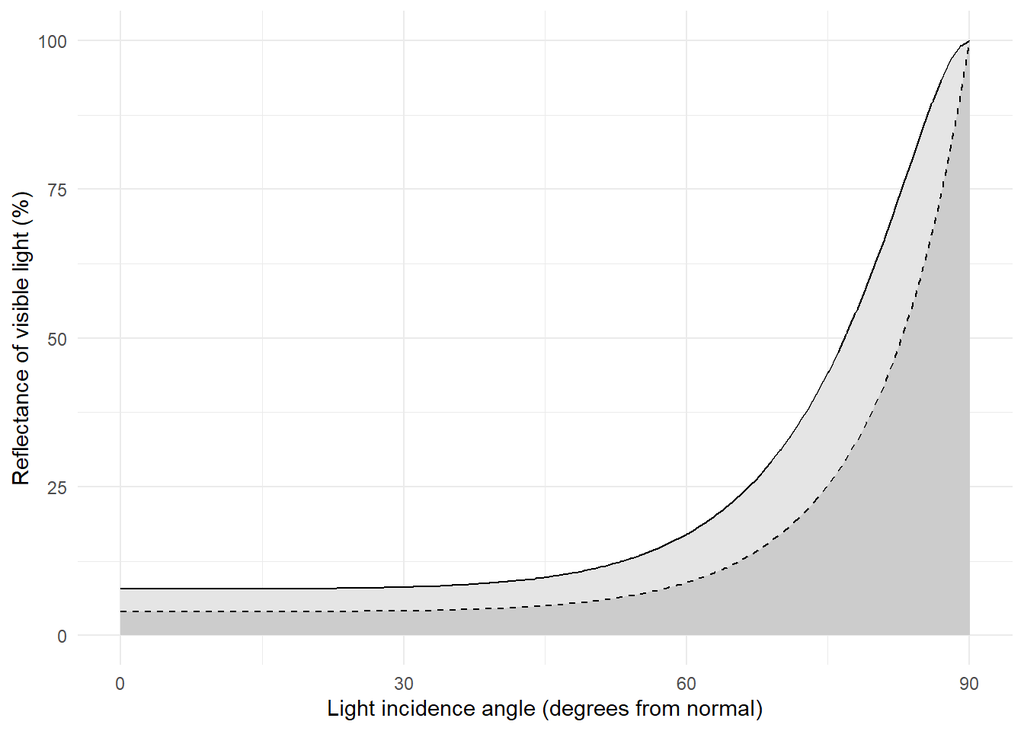

Figure 9: Reflectance of a crown glass or acrylic pane in air as a function of the angle of incidence of light. The dark grey area under the dashed line describes the light reflected by the air to glass (or entrance) interface and the pale grey area describes the light reflected at the glass to air (or exit) interface and the solid line the sum of them. The minimum reflectance at the first interface is 4%. Computed based on a relative refractive index ($n$) of 1.5, ignoring the higher order reflections of light bouncing back and forth within the glass.

**Practical examples**

The fraction of the incident light reflected by the glass or plastic roof of a greenhouse depends on the angle of incidence of the light, making the orientation and inclination of the roof play an important role in determining the transmittance of daylight at different times of the day and seasons of the year.

The same applies to plastic films and sheets used to filter-out UV radiation in field experiments: the transmittance of the filters will vary reflecting proportionally more PAR and UV radiation when the angle of incidence of sunlight is shallower.

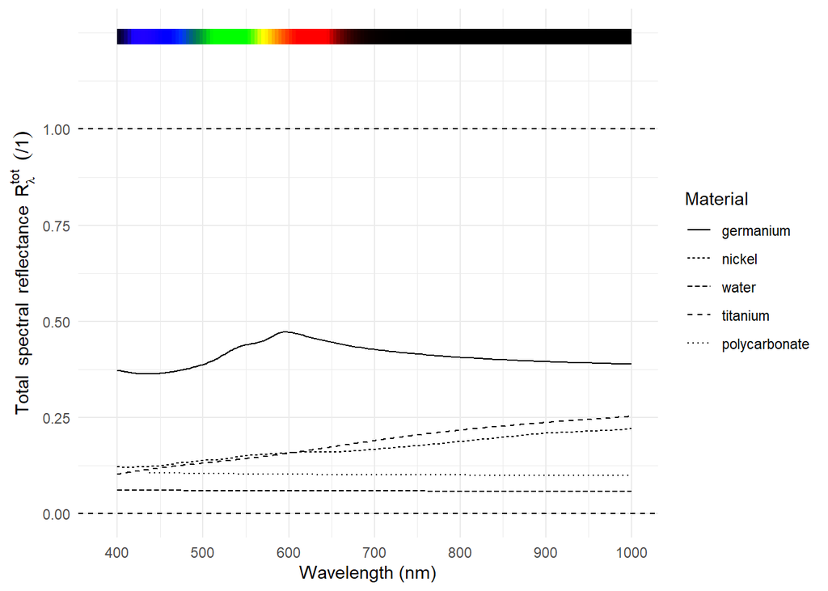

Figure 10: Spectral reflectance of different materials computed from the spectral refractive index $n_\lambda$ for an angle of incidence of $60^\circ$ away from the normal. Within each type of material $n_\lambda$ can vary and a result of oxydation of metal surfaces and additives and surface coatings on glass and plastic sheets.

On a rough surface, different points of the receiving surface are at different angles to the light beam, thus the equations above do not apply to the angle between the light beam and the plate as a whole. In addition, inclusions like air bubbles and small particles of a material with a different $n$ than the material matrix create additional interfaces within the plate. In all these cases, different photons are reflected at different angles, scattering the light. These are some of the properties used for making diffusive plates from clear materials. In a perfect diffuser internal absorptance $A_i = 0$, and half of the incoming photons exit from each face of a thin plate.

**Refractive index**

The refractive index, $n$, is a property of a material, but we must remember that, for example, corrosion of the surface of a metal plate, changes the material at the interface with air into an oxide. Thus, the corresponding value of $n$ also changes. Furthermore, corrosion of a polished metal surface frequently increases roughness, and thus scattering of the reflected light can also increase.

When the material does not absorb any of the photons travelling through it, i.e., its internal absorptance $A_i = 0$, and consequently, its internal transmittance $T_i = 1$, total transmittance is given by $T_t = 1 - R_t$, where $R_t$ is the total reflectance.

**Examples**

The surface of a water body reflects more light when the sun is low in the sky than at noon, at least if the surface of the air-water interface is horizontal and undisturbed by waves. Waves can be expected to increase reflectance when the sun is high in the sky by changing the average angle of incidence away from the normal, but to decrease it when the sun is low in the sky by altering the average angle of incidence in the opposite direction.

In the absence of waves, specular reflection predominates, and how the surface looks to us depends on our position relative to the sun and clouds. With waves, how the water surface looks to us will be less dependent on our position and we will no longer recognize the reflection of clouds and the sun.

*Add photographs?*

Many materials do absorb photons as they travel through them. The proportion of the photons incident at the surface and not reflected, i.e., entering the medium that remain at different depths in the medium depends on how many are absorbed or have deviated from their original direction of travel. Thus, absorption and scattering within a medium attenuate the light beam as photons travel through the medium, as discussed next.

### Attenuation

We use the term *attenuation* irrespective of whether the decrease in irradiance and radiance is due to absorption, scattering or reflection. *Absorption* implies that the energy is transferred to the medium causing the attenuation, while *reflection* and *scattering* as discussed above, are due to changes in the angle or direction in which light propagates. Absorption and scattering are “inherent optical processes”, because they depend on the characteristics of the material itself and are independent of the light field. In addition, re-emission of absorbed photons as fluorescence can moderate overall attenuation as well as alter the spectral composition. Bioluminiscence, emission of light by conversion of other forms of energy into light is possible, and can be important in aquatic systems. We next discuss how light interacts with a medium as it travels through it, considering absorption and scattering.

The number of photons absorbed, or amount of energy transferred, depends on the distance travelled within the medium, thus a gradient is created along the light path. In the simple case of a light beam normal to the boundaries of a “slice” of a non scattering material, such as a true solution in the cuvette of a spectrophotometer, the length of the path is given by the thickness of the “slice”.

At shallower angles of incidence, the effective path becomes longer Figure 11. However, the angle used to compute the length of the path is not the angle of incidence $\alpha$ because refraction changes this angle into $\beta$. Specular reflectance takes place symmetrically to the incidence angle, at angle $\alpha^\prime$. The value of $\beta$ is dependent on $n$, the diagram was computed for $n = 1.36$ Figure 11..

[figure not shown]

Figure 11: Refraction alters the angle of the beam, creating reflection but also displaces the transmitted light beam, modifying the path length. [From Wiki Commons](https://commons.wikimedia.org/wiki/File:Beam-displacement-inv.svg)

Radiance is not only attenuated, it can also be added to the directly transmitted beam, coming from different directions, due to elastic scattering, by which a photon changes direction but not wavelength or energy level[^3]. An example of this is Raleigh scattering by very small particles, which causes the scattering of light in a rainbow. A further, wavelength-specific gain of radiance into the direct path is possible through inelastic processes like fluorescence, where a photon is absorbed by the material and reemitted as a photon with a longer wavelength and lower energy level, and through Raman scattering. The elastic and inelastic scattered radiances are denoted as $L^E$ and $L^I$, respectively. Internal sources of radiance, $L^S$, like bioluminescence of biological organisms or cells contribute also to the detected radiance. The path of the light beam through a thin horizontal layer with thickness $\Delta z=z_1-z_0$ is shown schematically in Figure 12.

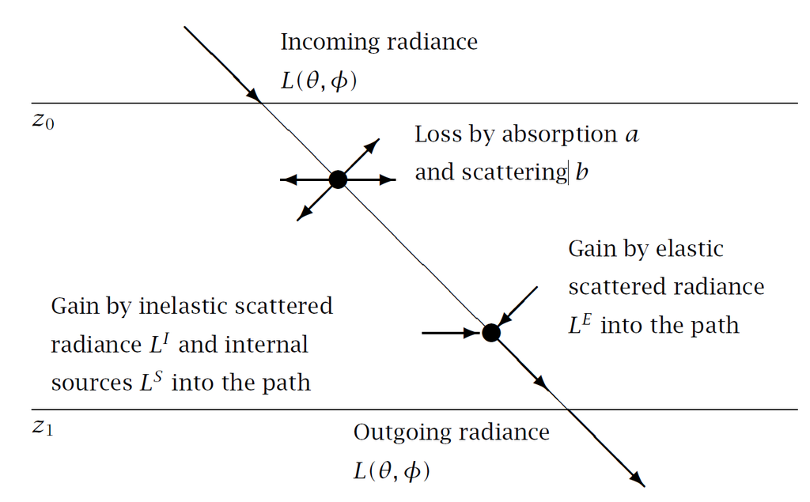

Figure 12: Path of the radiance and influences of absorbing and scattering particles in a thin homogeneous horizontal layer of air or water. The layer is separated from other layers of different characteristics by boundary lines at height $z_0$ and $z_1$.

Putting together the different components described above, the radiative transfer equation is obtained
$$\cos\theta\,\frac{{\rm d}L}{{\rm d}z} = -(a+s)\times L + L^E + L^I + L^S \label{equ_rte}$$
The dependencies of $L$ on $\lambda$, $\theta$, and $\phi$ are omitted here for brevity. No exact analytical solution to the radiative transfer equation exists, hence it is necessary either to use numerical models or to use analytical approximations.

The parameters of the light field can be simulated by modelling the paths of photons, also called “ray tracing”. For an infinite number of photons, the light field parameters reach their exact values asymptotically. The advantage of numerical simulation methods is a relatively simple structure of the program, but its disadvantage is the time-consuming computation involved. Details of the application of the Monte Carlo method to simulations are explained for example by Prahl et al. (1989), Wang, Jacques, and Zheng (1995)[^4], or Mobley (1994).

$$L(z_1) = L(z_0)\times \mathrm{e}^{-\frac{a\cdot(z_1-z_0)}{\cos\theta}}$$

The radiance value at the upper boundary, $L(z_0)$, is presumed known. This equation is known as Beer’s law (or Lambert’s law, Bouguer’s law, Beer-Lambert law), and describes any instance of exponential attenuation of light and is exact only for purely absorbing media—i.e., media that do not scatter radiation. It is of direct application in analytical chemistry, as it describes the direct proportionality of absorbance ($A$) to the concentration of a “coloured” solute in a transparent solvent. True solutions are optically homogeneous, while suspensions and aerosols are not. The latter scatter light and their behaviour is different from that described by Beer’s law. In chemistry, Beer’s law is formulated in a simplified way by assuming a collimated light beam incident at 90 degrees

$$I_\lambda(z_1) = I_\lambda(z_0) \times \mathrm{e}^{-k_\lambda\times c\times l}$$
where $I_\lambda(z_0)$ and $I_\lambda(z_1)$ are irradiances, $k_\lambda$ is the attenuation coefficient of the solute, $c$ is the concentration of the solute, and $l = z_1 - z_0$ is the path length. As the value of $k_\lambda$ is a function of wavelength, $\lambda$, how much $I$ is attenuated also depends on $\lambda$.

This equation can be used to compute irradiance at any point in the path by varying $l$ if $k_\lambda$ and $c$ are known. In chemical analysis, the equation is used to estimate $c$ with $k_\lambda$ and $l$ known. For a valid estimate, all the quantities must be expressed in coherent units, and the solvent should not absorb photons in the wavelength range of interest. In practice, in most cases both the pure solvent and the solution are measured, and the effect of the solute obtained by difference. A calibration curve based on a dilution series of known concentrations is safest when the pure solute is available.

Irradiance in a solution changes with path length following an exponential attenuation curve, i.e., the curve is asymptotic Figure 13.

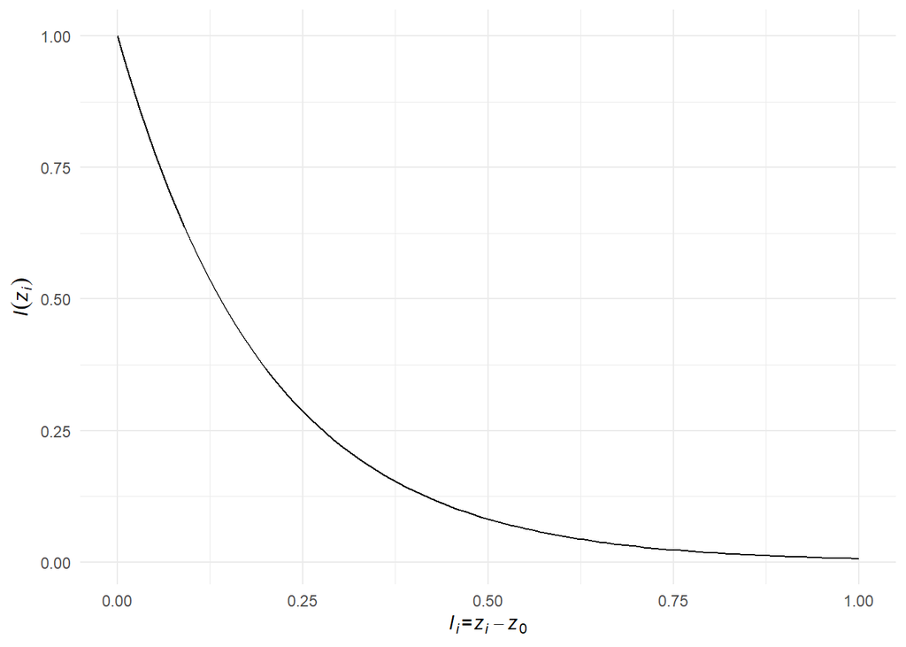

Figure 13: Hypothetical light attenuation curve computed with the Beer-Lambert equation assuming $k \times c = 5$. This figure illustrates the shape of the curve, while the $z_i - z_0$ are arbitrary path lengths $l$.

**Radiation transfer models**

Radiation transfer models like TUV and libradtran simulate the modifying effect of the atmosphere on extraterrestrial solar spectral irradiance to estimate the daylight spectrum at ground level or at different elevations within the atmosphere. Importantly, these models compute the effect of the surface albedo, aerosols, clouds and particles in the atmosphere.

The output from both models can be either spectral irradiance or spectral radiance. They also estimate the direct and diffuse components, as well as the upwelling scattered radiation from the ground surface.

Both [libradtran](https://www.libradtran.org/) (Emde et al. 2016) and [TUV](https://www2.acom.ucar.edu/modeling/tuv-download) models can be installed and run locally, while a simplified interactive on-line application [Quick TUV Calculator](https://www.acom.ucar.edu/Models/TUV/Interactive_TUV/) is available. R package ‘photobiologyInOut’ can import data generated by these models into R objects. R package ‘forqat’ can do simulation with TUV, either locally installed or using the Quick TUV API, directly from within R.

Radiation transfer models have also been developed for simulation of the within canopies (e.g., Chelle, Andrieu, and Bouatouch 1998; Chelle et al. 2007) and as well as within leaves, e.g. PROSPECT (Feret et al. 2008; Li et al. 2023).

### Radiation, Atoms and Molecules

**I propose here a new section, that needs to be consistent with what Wolfgang will write about related subjects.**

**Pigments**

A *pigment* is a light absorbing chemical or biochemical molecule. Which wavelengths are absorbed or not is determined by the allowed energy levels and transitions because only photons with “matching” energy can be absorbed. Pigments excited by interaction with one or more photons are said to be “excited”. The additional energy absorbed from photons is dissipated through different excitation decay mechanisms.

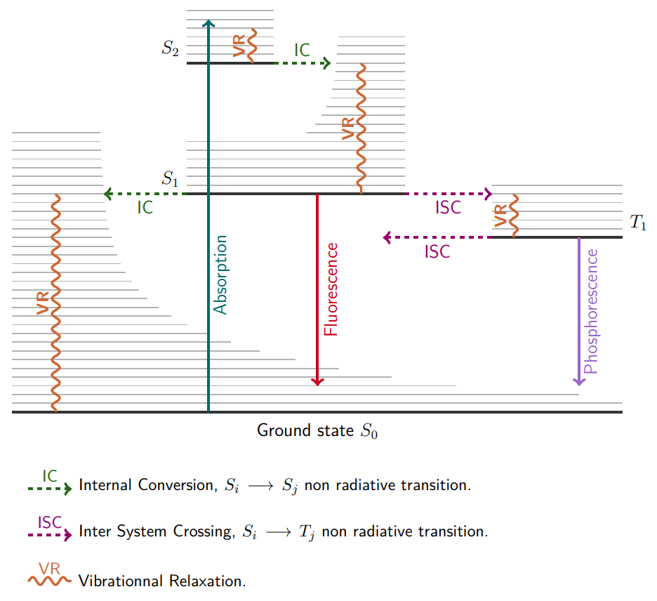

Figure 14: The Perrin-Jablonski diagram showing energy states. The absorption of a photon is depicted together with the different pathways for energy disipation. Energy increases upwards on the vertical axis. (Modified [diagram by Germain Salvato-Vallverdu.](https://texample.net/tikz/examples/the-perrin-jablonski-diagram/).)

**Some ideas of what the contents could include**

- Photon absorption and molecule/atom excitation
- Decay/quenching: thermal, fluorescence, phosphorescence
- Luminescence
- molar attenuation
- quantum yield
- molar cross section

### Quantities Describing Light-Matter Interactions

Radiation incident on an object can be partitioned into three components based on its fate,

$$1 = R^\mathrm{tot} + \alpha + T^\mathrm{tot}$$
where $R^\mathrm{tot}$, $\alpha$, and $T^\mathrm{tot}$ are expressed as fractions Table 5. Alternatively, they can be expressed as percentages.

If $I_0$ is the irradiance on the surface of an object, the “irradiance” entering the body of the object is given by $I_0 \times (1 - R^\mathrm{tot})$. The irradiance exiting the opposite side of the object is given by $I_0 \times T^\mathrm{tot}$.

Internal transmittance $T^\mathrm{int}$ considers only the radiation entering the object, thus,

$$1 = \alpha + T^\mathrm{int}$$
from which it follows that always $T^\mathrm{int} \geq T^\mathrm{tot}$. To convert $T^\mathrm{int}$ into $T^\mathrm{tot}$ we need to know $R^\mathrm{tot}$,

$$T^\mathrm{tot} = T^\mathrm{int} \times (1 - R^\mathrm{tot})$$
and
$$T^\mathrm{int} = \frac{T^\mathrm{tot}}{1 - R^\mathrm{tot}}$$

Absorbance ($A$) is a logarithm-transformed quantity. In Chemistry $A$ is most frequently computed using base-10 logarithm, while is some other fiels natural or $e$-based logarithms are used.

$$A = -\log_{10}(1 - \alpha) = -\log_{10}(T^\mathrm{int}) = -\log_{10}(R^\mathrm{tot} + T^\mathrm{tot})$$

We use $A$ as symbol for decadic absorbance, for which $A_{10}$ may be used in other publications. We use the subscript to indicate the wavelength in nanometres (nm), e.g., $A_{663}$.

**Example**

As discussed earlier in this chapter, in the Beer-Lambert equation solute concentration enters as an exponent, i.e., a power of $e$. Thus, $A \propto c$, and a convenient quantity for assessing concentrations of a solute as $c = A \times k$ where $k$ is the slope of an empirical calibration curve.

In chemistry and biochemistry when using a spectrophotometer it is the norm to measure a *blank* as reference. The assumption is that $R^\mathrm{tot}$ is the same for the blank and the sample, thus the difference between blank and sample, corresponds to absorptance, $\alpha$, or $1 - T^\mathrm{int}$. As the solvent is used for the blank, the difference in absorptance can be attributed to the solute.

Table 5: Physical quantities that describe the interaction of objects and light and related quantities describing intensive properties of materials.

| Symbol | Unit | Description |
| --- | --- | --- |
| $R^\mathrm{tot}$ | fraction | Total reflectance: |
| $R^\mathrm{spcl}$ | fraction | Specular reflectance: |
| $R^\mathrm{diff}$ | fraction | Diffuse reflectance: |
| $n$ | numeric | Refractive index: |
| $T^\mathrm{tot}$ | fraction | Total transmittance: |
| $T^\mathrm{int}$ | fraction | Internal transmittance: |
| $\alpha$ | fraction | Absorptance: |
| $A$ | a.u. | Absorbance: |

## Further Reading

The book *The Optics of Life: A Biologist’s Guide to Light in Nature* (Johnsen 2012) gives a detailed account of the different aspects of optics as the relate to organisms. Although animales are emphasized more than plants in the examples, overall it is highly relevant plant biologists.

The classic book *Biophysical Ecology* (Gates 2012) covers a broader range of subjects and discusses implications for Ecology. It is relevant to the current and to the following chapter.

The book *Photobiology: The Science of Light and Life* (Björn 2015) covers widely photobiology of animals and plants and includes introductory chapters on the physics of light.

The book *Nature’s Palette: The Science of Plant Color* (Lee 2010) focuses on plant pigments and other optical properties that are visualised as colours.

## Technical References

The *Compendium of Chemical Terminology* (Kaiser and Chalk 2020) (“IUPAC Gold Book”) provides up-to-date guidelines on the use of terminology and symbols used in chemistry including photochemistry.

NIST publication 330 (Newell and Tiesinga 2019) describes the International System of Units (SI) in great detail, and together with the IUPAC Gold Book can help clarify the use of units in and technical publications.

## References

Björn, L. O. 2015. *Photobiology: The Science of Light and Life*. 3rd ed. New York: Springer. https://books.google.fi/books?id=VDgLBgAAQBAJ.

Chelle, Michaël, Bruno Andrieu, and Kadi Bouatouch. 1998. “Nested Radiosity for Plant Canopies.” *The Visual Computer* 14 (3): 109–25. https://doi.org/10.1007/s003710050127.

Chelle, Michaël, Jochem B Evers, Didier Combes, Claude Varlet-Grancher, Jan Vos, and Bruno Andrieu. 2007. “Simulation of the Three-Dimensional Distribution of the Red: Far-Red Ratio Within Crop Canopies.” *New Phytologist* 176 (1): 223–34. https://doi.org/10.1111/j.1469-8137.2007.02161.x.

Eichler, H.- J., A. Fleischner, J. Kross, M. Krystek, H. Lang, H. Niedrig, H. Rauch, et al. 1993. *Bergmann, Schaefer: Lehrbuch Der Experimentalphysik Band 3: Optik*. Edited by H. Niedrig. Verlag Walter de Gruyter Berlin/New York.

Emde, Claudia, Robert Buras-Schnell, Arve Kylling, Bernhard Mayer, Josef Gasteiger, Ulrich Hamann, Jonas Kylling, et al. 2016. “The libRadtran Software Package for Radiative Transfer Calculations (Version 2.0.1).” *Geoscientific Model Development* 9: 1647–72. https://doi.org/10.5194/gmd-9-1647-2016.

Feret, Jean-Baptiste, Christophe François, Gregory P. Asner, Anatoly A. Gitelson, Roberta E. Martin, Luc P. R. Bidel, Susan L. Ustin, Guerric le Maire, and Stéphane Jacquemoud. 2008. “PROSPECT-4 and 5: Advances in the Leaf Optical Properties Model Separating Photosynthetic Pigments.” *Remote Sensing of Environment* 112: 3030–43. https://doi.org/10.1016/j.rse.2008.02.012.

Gates, David M. 2012. *Biophysical Ecology*. Dover Publications, Incorporated.

Johnsen, Sönke. 2012. *The Optics of Life: A Biologist’s Guide to Light in Nature*. Princeton, NJ: Princeton University Press.

Kaiser, Jan, and Stuart Chalk, eds. 2020. *Compendium of Chemical Terminology*. International Union of Pure; Applied Chemistry. https://doi.org/10.1351/goldbook.

Lee, David. 2010. *Nature’s Palette: The Science of Plant Color*. University of Chicago Press.

Li, Xiao, Zhongqiu Sun, Shan Lu, and Kenji Omasa. 2023. “PROSPECULAR: A Model for Simulating Multi-Angular Spectral Properties of Leaves by Coupling PROSPECT with a Specular Function.” *Remote Sensing of Environment* 297 (November): 113754. https://doi.org/10.1016/j.rse.2023.113754.

McCree, K. J. 1972. “Test of Current Definitions of Photosynthetically Active Radiation Against Leaf Photosynthesis Data.” *Agricultural Meteorology* 10: 443–53. https://doi.org/10.1016/0002-1571(72)90045-3.

Mobley, C. D. 1994. *Light and Water - Radiative Transfer in Natural Waters*. San Diego: Academic Press.

Newell, David B, and Eite Tiesinga. 2019. *The International System of Units (SI):: 2019 Edition*. National Institute of Standards; Technology. https://doi.org/10.6028/nist.sp.330-2019.

Prahl, S. A., M. Keijzer, S. L. Jacques, and A. J. Welch. 1989. “A Monte Carlo Model of Light Propagation in Tissue.” In *SPIE Proceedings of Dosimetry of Laser Radiation in Medicine and Biology*, edited by G. J. Müller and D. H. Sliney, IS 5:102–11.

Schwiegerling, Jim. 2004. *Field Guide to Visual and Ophthalmic Optics*. Bellingham, Wash.: SPIE Press.

Sellaro, Romina, Marı́a Crepy, Santiago Ariel Trupkin, Elizabeth Karayekov, Ana Sabrina Buchovsky, Constanza Rossi, and Jorge Jose Casal. 2010. “Cryptochrome as a Sensor of the Blue / Green Ratio of Natural Radiation in Arabidopsis.” *Plant Physiology* 154: 401–9. https://doi.org/10.1104/pp.110.160820.

Smith, H. 1981. *Plants and the Daylight Spectrum*. London: Academic Press.

Wang, L.- H., S. L. Jacques, and L.- Q. Zheng. 1995. “MCML - Monte Carlo Modeling of Photon Transport in Multi-Layered Tissues.” *Computer Methods and Programs in Biomedicine* 47: 131–46. https://doi.org/10.1016/0169-2607(95)01640-F.

Zhen, Shuyang, Marc W. van Iersel, and Bruce Bugbee. 2022. “Photosynthesis in Sun and Shade: The Surprising Importance of Far‐red Photons.” *New Phytologist* 236 (2): 538–46. https://doi.org/10.1111/nph.18375.

## Footnotes

[^1]: These equations are a system of four partial differential equations describing classical electromagnetism.
[^2]: Wavelength and frequency are related to each other by the speed of light, according to $\nu = c / \lambda$ where $c$ is speed of light in vacuum. Consequently there are two equivalent formulations for the equations.
[^3]: If the beam is very narrow, like from a laser, no contribution from scaterring outside the beam will be present, but if the beam can be considered to extend across the plane of the slice, scattering in the beam will in part be compensated by nearby scattering.
[^4]: Their programs are available from the website of [Oregon Medical Laser Center](http://omlc.ogi.edu/software/mc/) at http://omlc.ogi.edu/software/mc/